# Technische notitie: uitbreiding GSED2510 D-score model met DDI/Van Wiechen-items

Author

Iris Eekhout

Published

July 2, 2026

# Doel van deze technische notitie

Deze technische notitie beschrijft de stappen die zijn gezet om het bestaande **GSED2510 D-score model** uit te breiden met Nederlandse DDI/Van Wiechen-items. Het doel van deze uitbreiding is om itemparameters te schatten voor Van Wiechen/DDI-items op de meest recente GSED2510-metriek, zodat Nederlandse JGZ-data op een consistente manier kunnen worden omgezet naar D-scores.

Deze notitie is bedoeld als technische onderbouwing voor vervolgprojecten waarin de D-score wordt toegepast in de Nederlandse JGZ-praktijk.

# Achtergrond en motivatie

De D-score biedt een gemeenschappelijke schaal voor vroege kindontwikkeling. Voor toepassing binnen de Nederlandse JGZ is het noodzakelijk dat het Van Wiechenonderzoek / DDI-instrument gekoppeld is aan de meest recente GSED-calibratie. In eerdere analyses is al gewerkt met een eerdere D-score-calibratie. Voor verdere ontwikkeling van richtlijnen, normreferenties en dashboards is echter een update naar de nieuwste GSED2510-metriek nodig.

Het huidige werk richt zich daarom op het uitbreiden van het GSED2510-model met DDI-items. Daarbij worden items die al een directe relatie hebben met GSED-items gebruikt als vaste ankerparameters. Voor overige DDI-items worden nieuwe itemparameters geschat op basis van beschikbare Nederlandse en aanvullende DDI-data.

# Databronnen

## Brongegevens

Voor deze modeluitbreiding zijn DDI/Van Wiechen-data opgehaald uit het `gseddata`-pakket. De gebruikte data bestaan uit longitudinale itemresponsen van kinderen op verschillende leeftijden.

De analyse maakt gebruik van:

- DDI/Van Wiechen-itemresponsen;
- leeftijd in dagen (`agedays`);
- subject-ID (`subjid`);
- cohortinformatie;
- landcode;
- meetmomentinformatie.

## Inclusie van aanvullende DDI-cohorten

In het script is ingesteld dat aanvullende DDI-cohorten uit `gseddata::gsed_lean` worden meegenomen:

**Toon/verberg R-code**

```r
include_extra_ddi_cohorts <- TRUE
```

De ruwe itemdata worden beperkt tot binaire responsen:

`pad$itm <- dplyr::filter(pad$itm, value %in% c(0, 1))`

# Datavoorbewerking

## Long-form dataset

De DDI-itemresponsen worden eerst in long-form opgebouwd door de itemdata te koppelen aan visit-informatie op basis van `subjid` en `agedays`. Hierbij worden de volgende variabelen geselecteerd:

- `cohort`;
- `country`;
- `subjid`;
- `agedays`;
- `pair`;
- `ins`;
- `item`;
- `response`.

**Toon/verberg R-code**

```r
items_ddi <- dscore::get_itemnames(ins = "ddi")

pad <- gseddata::get_data(adm = ".", items = items_ddi, min_cat = 10)
pad$itm <- dplyr::filter(pad$itm, value %in% c(0, 1))

long <- dplyr::left_join(
  pad$itm,
  pad$visit,
  by = c("subjid", "agedays")
) |>
  dplyr::mutate(
    subjid = as.character(subjid),
    ins = "DDI",
    pair = agedays
  ) |>
  dplyr::select(
    cohort,
    country = ctrycd,
    subjid,
    agedays,
    pair,
    ins,
    item,
    response = value
  )
```

## Wide-form dataset

Voor het fitten van het D-score model wordt de dataset omgezet naar wide-form: één rij per kind-meetmoment, met de itemresponsen als kolommen.

**Toon/verberg R-code**

```r
dat <- long |>
  tidyr::pivot_wider(
    id_cols = c(cohort, country, subjid, agedays, pair, ins),
    names_from = item,
    values_from = response
  ) |>
  dplyr::arrange(subjid, agedays)
```

# Koppeling met bestaande GSED2510-itemparameters

## Identificeren van DDI-items die al in GSED voorkomen

Een deel van de DDI-items is direct gekoppeld aan GSED-items. Deze items kunnen worden gebruikt als ankers, omdat daarvoor al itemparameters beschikbaar zijn in het GSED2510-model.

**Toon/verberg R-code**

```r
ddi_in_gsed <- dscore::builtin_translate |>
  dplyr::filter(grepl("^ddi", gsed)) |>
  dplyr::mutate(tau = get_tau(gsed3))
ddi_in_gsed |> select(gsed, gsed3, label, tau) |>
  left_join(dscore::builtin_itemtable, by = c("gsed" = "item"))
```

```
        gsed     gsed3                                                 label.x
1  ddigmd057 gl1gmd004                 A4  Lifts head in prone 45 degrees (2X)
2  ddigmd061 gl1gmd010                       A10 Balances head while supported
3  ddifmd010 gl1gmd027 A27 Picks up small object between thumb and finger (2X)
4  ddifmm012 gl1gmd030                      "A30 Plays ""give-and-take"" (3X)"
5  ddicmm029 gl1lgd002                          B2  Reacts when spoken to (2X)
6  ddicmm030 gl1lgd003                             B3  Smiles in response (2X)
7  ddicmm034 gl1lgd008                               B8  Babbles while playing
8  ddicmd141 gl1lgd018                  B18 Identifies 2 objects you name (2X)
9  ddicmd044 gl1lgd023                        B23 Points at 5 pictures in book
10 ddicmm041 gl1lgd026                B26 Says sentences with 2 words together
11 ddicmm047 gl1lgd043                     B43 Talks easily about daily events
12 ddifmd001 gl1fmd001                                   C1  Fixates eyes (2X)
13 ddifmd013 gl1fmd026                       C26 Builds tower of 2 blocks (2X)
14 ddifmd023 gl1fmd045                       C45 Imitates building bridge (2X)
```

[output cut: 17 more lines]

## Inlezen van het bestaande GSED2510-model

Het bestaande GSED2510 Rasch-model wordt ingelezen vanuit een lokaal opgeslagen RDS-bestand.

**Toon/verberg R-code**

```r
modelgsed2510 <- readRDS("C:/Users/eekhouti/OneDrive - TNO/Projecten/gsed/Phase 2/202510/281_0_phase_1+2/model.Rds")
```

## Afleiden van vaste itemparameters

De beta-parameters uit het bestaande model worden omgezet naar tau-parameters. Vervolgens worden itemnamen waar nodig vertaald van GSED- naar DDI-namen. De DDI-items die voorkomen in de wide-form dataset worden geselecteerd als vaste parameters.

**Toon/verberg R-code**

```r
fixed_gsd <- -modelgsed2510$fit$betapar
lookup <- setNames(ddi_in_gsed$gsed, ddi_in_gsed$gsed3)

new_names <- ifelse(
  names(fixed_gsd) %in% names(lookup),
  lookup[names(fixed_gsd)],
  names(fixed_gsd)
)

names(fixed_gsd) <- new_names

ddi_fixed <- fixed_gsd[names(fixed_gsd) %in% names(dat)]
```

# Itemselectie en kwaliteitscontroles

Voorafgaand aan het fitten zijn verschillende controles uitgevoerd om te bepalen welke DDI-items voldoende informatie bevatten voor modelschatting.

## Selectie van DDI-items

**Toon/verberg R-code**

```r
items <- dat |>
  dplyr::select(dplyr::starts_with("ddi")) |>
  colnames()
```

## Controle 1: minimaal aantal geldige responsen

Items met minder dan 10 geldige responsen worden uitgesloten. In de huidige analyse zijn op basis van deze stap geen items verwijderd.

**Toon/verberg R-code**

```r
nvalid <- colSums(!is.na(dat[, items]))
sum(nvalid < 10)
```

```
[1] 0
```

**Toon/verberg R-code**

```r
items[nvalid < 10]
```

```
character(0)
```

**Toon/verberg R-code**

```r
items <- items[nvalid >= 10]
```

## Controle 2: minimaal aantal responsen in de minst voorkomende categorie

Items worden alleen behouden wanneer beide antwoordcategorieën voldoende voorkomen. In de huidige analyse zijn op basis van deze stap geen items verwijderd.

**Toon/verberg R-code**

```r
keep <- sapply(dat[, items], function(x) min(table(x)) >= 10)
sum(!keep)
```

```
[1] 0
```

**Toon/verberg R-code**

```r
names(keep[!keep])
```

```
character(0)
```

**Toon/verberg R-code**

```r
items <- items[keep]
```

## Controle 3: voldoende spreiding

Items zonder voldoende spreiding worden uitgesloten. Hiervoor is een standaarddeviatiegrens van 0.01 gebruikt. In de huidige analyse zijn op basis van deze stap geen items verwijderd.

**Toon/verberg R-code**

```r
keep <- sapply(dat[, items], function(x) sd(x, na.rm = TRUE) > 0.01)
sum(!keep)
```

```
[1] 0
```

**Toon/verberg R-code**

```r
names(keep[!keep])
```

```
character(0)
```

**Toon/verberg R-code**

```r
items <- items[keep]
```

# Voorbereiding voor modelfit

De uiteindelijke modeldataset bevat de geselecteerde DDI-items en administratieve variabelen.

**Toon/verberg R-code**

```r
data <- dat |>
  dplyr::select(dplyr::all_of(items), subjid, agedays, cohort, country)

varlist <- list(
  adm = c("subjid", "agedays", "cohort", "country"),
  items = items
)
```

De volgende argumenten zijn van cruciaal van belang in `fit_dmodel`:

- anchors
- data_package
- transform

**anchors**

We kunnen twee anchor items definieren, deze worden dan gebruik om de schaling af te stemmen met het juiste model. Gebruik hiervoor twee items (willekeurig) die beide gefixed zijn en dus al GSED parameters (beta en tau) hebben. *Note: het weglaten van anchors levert een andere oplossing op als we verder niets doen met `data_package` en `transform` - zie ook `scripts/model_ddi2510_anchor_comp.R`*

**Toon/verberg R-code**

```r
#modelgsed2510$itembank %>% filter(item %in%  names(lookup))
anchors <- modelgsed2510$itembank %>% filter(item %in%  c("gl1fmd026", "gl1lgd026")) %>% dplyr::select(tau) %>% unlist
anchor_names <- ifelse(c("gl1fmd026", "gl1lgd026") %in% names(lookup),
                    lookup[c("gl1fmd026", "gl1lgd026")],
                    names(fixed_gsd))
names(anchors) <- anchor_names
names(anchors) %in% names(data)
```

```
[1] TRUE TRUE
```

**transform**

Intercept en slope uit model$transform is beter en cleaner om te doen ipv de anchors. Alleen moet dan `data_package` argument expliciet als “” ingegeven worden, anders worden transform parameters overschreven.

**Conclusie: we geven transfrom = modelgsed2510$transform mee, met data_package = ““. Dit zorgt voor een robuuste toepassing, onafhankelijk van items die wel of niet voorkomen in de data.**

# Modelschatting (1)

Het DDI-uitbreidingsmodel wordt gefit met `dmetric::fit_dmodel()`. Hierbij worden beschikbare vaste DDI/GSED-ankerparameters gebruikt om de nieuwe DDI-items op de GSED2510-schaal te plaatsen.

**Toon/verberg R-code**

```r
i <- length(varlist$items)
f <- length(ddi_fixed)
model_name <- paste("ddi", i, f, sep = "_")
model_name
```

```
[1] "ddi_74_14"
```

**Toon/verberg R-code**

```r
model <- dmetric::fit_dmodel(
  data = data,
  varlist = varlist,
  name = model_name,
  b_fixed = ddi_fixed,
  data_package = "",
  transform = modelgsed2510$transform
)
```

# Modeldiagnostiek

## Itemfit van vastgezette items

Eerst is specifiek gekeken naar items met vaste GSED-parameters en mogelijke misfit.

**Toon/verberg R-code**

```r
model$item_fit |>
  dplyr::filter((outfit > 1 | infit > 1) & item %in% names(ddi_fixed))
```

```
# A tibble: 4 × 8
  item          n outfit     qo outfit_z infit     qi infit_z
  <chr>     <int>  <dbl>  <dbl>    <dbl> <dbl>  <dbl>   <dbl>
1 ddicmd044  3226  0.775 0.0918   -2.63   1.15 0.0373    3.89
2 ddifmd010  3236  1.07  0.0832    0.875  1.14 0.0282    4.70
3 ddifmd013  2949  0.906 0.0465   -2.08   1.03 0.0210    1.25
4 ddigmd061  3465  2.15  0.146     6.05   4.04 0.0959   18.6
```

> Hieruit blijkt dat voor item `ddigmd061` de vastgezette model parameter niet past bij de data. We besluiten dus om dit item vrij te laten schatten in een nieuw model.

Vergelijk de fit van de fixed items met de itemfit in het gsed2510 model voor deze items. Idealiter zou dit infit en outfit vergelijkbaar moeten zijn tussen de modellen.

**Toon/verberg R-code**

```r
model$item_fit |> select(item, n, outfit, infit) |> filter(item %in% names(ddi_fixed)) |>
  left_join(ddi_in_gsed, by = c("item"="gsed")) |> select(item:infit, gsed3) |>
  left_join({modelgsed2510$item_fit |> select(item, n, outfit, infit)}, by= c("gsed3" = "item"))
```

```
# A tibble: 14 × 8
   item        n.x outfit.x infit.x gsed3       n.y outfit.y infit.y
   <chr>     <int>    <dbl>   <dbl> <chr>     <int>    <dbl>   <dbl>
 1 ddicmm029  1984    0.263   0.305 gl1lgd002  2310    0.822   0.949
 2 ddicmm030  3513    0.502   0.632 gl1lgd003  2934    0.701   0.936
 3 ddicmm041  4224    0.579   0.694 gl1lgd026  2446    0.760   0.824
 4 ddicmd044  3226    0.775   1.15  gl1lgd023  2381    0.913   0.917
 5 ddicmm047  2232    0.475   0.648 gl1lgd043  2467    0.852   0.899
 6 ddicmd141  2883    0.689   0.779 gl1lgd018  2398    0.786   0.845
 7 ddifmd001  1971    0.340   0.557 gl1fmd001  2940    0.946   0.848
 8 ddifmd010  3236    1.07    1.14  gl1gmd027  2172    1.02    0.924
 9 ddifmm012  3344    0.467   0.610 gl1gmd030  2612    1.13    0.949
10 ddifmd013  2949    0.906   1.03  gl1fmd026  2354    0.908   0.938
11 ddifmd023  2183    0.604   0.828 gl1fmd045  2824    0.816   0.875
12 ddifmd026  2327    0.543   0.751 gl1fmd047  1983    1.01    1.00
13 ddigmd057  2662    0.692   0.769 gl1gmd004  2902    0.704   0.834
14 ddigmd061  3465    2.15    4.04  gl1gmd010  2495    0.921   0.968
```

## Parameter estimates van vaste parameters

Door het vastzetten van de parameters van de DDI-items die direct gekoppeld zijn aan GSED items worden de schattingen van de DDI-item gekoppeld aan het core-model (GSED2510). We checken nog of de tau (d-score) parameter schattingen van de vast gezette items ook daadwerkelijk overeenkomen met de corresponderende items uit het gsed2510 core model:

*Dit is ingegeven in het model en dus meer een controle of de instellingen van het model daadwerkelijk goed doorkomen*

**Toon/verberg R-code**

```r
fix_tau <- ddi_in_gsed |> select(gsed, gsed3, tau) |> rename(item = gsed) |> arrange(tau)
model_tau <- model$itembank |> filter(item %in% ddi_in_gsed$gsed) |> select(item, tau) |> rename(tau_est = tau) |> arrange(tau_est) |> mutate(tau_est = round(tau_est,2))
fix_tau |> left_join(model_tau, by = "item")
```

```
        item     gsed3   tau tau_est
1  ddifmd001 gl1fmd001  7.17    7.17
2  ddicmm029 gl1lgd002  8.56    8.56
3  ddicmm030 gl1lgd003 13.40   13.40
4  ddigmd057 gl1gmd004 18.32   18.32
5  ddigmd061 gl1gmd010 18.73   18.73
6  ddifmd010 gl1gmd027 38.28   38.28
7  ddifmm012 gl1gmd030 48.37   48.37
8  ddifmd013 gl1fmd026 55.02   55.02
9  ddicmd141 gl1lgd018 56.51   56.51
10 ddicmd044 gl1lgd023 61.92   61.92
11 ddicmm041 gl1lgd026 63.75   63.75
12 ddifmd023 gl1fmd045 74.04   74.04
13 ddicmm047 gl1lgd043 74.41   74.41
14 ddifmd026 gl1fmd047 74.97   74.97
15 ddicmm034 gl1lgd008    NA   36.65
```

## Losmaken van vaste parameters

In principe worden DDI-items die direct gekoppeld zijn aan GSED2510 als vaste parameters in het model opgenomen. Tijdens de analyse bleek echter dat de fixed-parameter fit voor item `ddigmd061` niet paste bij de data. Daarom is de vaste parameter voor dit item verwijderd, zodat dit item opnieuw vrij geschat kon worden.

**Toon/verberg R-code**

```r
ddi_fixed <- ddi_fixed[setdiff(names(ddi_fixed), "ddigmd061")]
```

# Modelschatting (2)

Het DDI-uitbreidingsmodel wordt gefit met `dmetric::fit_dmodel()`. Hierbij worden beschikbare vaste DDI/GSED-ankerparameters gebruikt om de nieuwe DDI-items op de GSED2510-schaal te plaatsen.

**Toon/verberg R-code**

```r
i <- length(varlist$items)
f <- length(ddi_fixed)
model_name <- paste("ddi", i, f, sep = "_")
model_name
```

```
[1] "ddi_74_13"
```

**Toon/verberg R-code**

```r
model <- dmetric::fit_dmodel(
  data = data,
  varlist = varlist,
  name = model_name,
  b_fixed = ddi_fixed,
  data_package = "",
  transform = modelgsed2510$transform
  )
```

# Modeldiagnostiek

## Itemfit

Eerst is specifiek gekeken naar items met vaste GSED-parameters en mogelijke misfit.

**Toon/verberg R-code**

```r
model$item_fit |>
  dplyr::filter((outfit > 1 | infit > 1) & item %in% names(fixed_gsd))
```

```
# A tibble: 3 × 8
  item          n outfit     qo outfit_z infit     qi infit_z
  <chr>     <int>  <dbl>  <dbl>    <dbl> <dbl>  <dbl>   <dbl>
1 ddicmd044  3226  0.776 0.0918    -2.62  1.15 0.0373    3.94
2 ddifmd010  3236  1.25  0.0863     2.72  1.34 0.0305   10.1
3 ddifmd013  2949  0.916 0.0466    -1.85  1.04 0.0210    1.72
```

> Hieruit blijkt dat voor item `ddifmd010` de vastgezette model parameter niet past bij de data. We besluiten dus om dit item vrij te laten schatten in een nieuw model.

## Behandeling van vaste parameters

De fixed-parameter fit voor item `ddifmd010` paste niet bij de data. Daarom is de vaste parameter voor dit item verwijderd, zodat dit item opnieuw vrij geschat kon worden.

**Toon/verberg R-code**

```r
ddi_fixed <- ddi_fixed[setdiff(names(ddi_fixed), "ddifmd010")]
```

# Modelschatting (3)

Het DDI-uitbreidingsmodel wordt gefit met `dmetric::fit_dmodel()`. Hierbij worden beschikbare vaste DDI/GSED-ankerparameters gebruikt om de nieuwe DDI-items op de GSED2510-schaal te plaatsen.

**Toon/verberg R-code**

```r
i <- length(varlist$items)
f <- length(ddi_fixed)
model_name <- paste("ddi", i, f, sep = "_")
model_name
```

```
[1] "ddi_74_12"
```

**Toon/verberg R-code**

```r
model <- dmetric::fit_dmodel(
  data = data,
  varlist = varlist,
  name = model_name,
  b_fixed = ddi_fixed,
  data_package = "",
  transform = modelgsed2510$transform
)
```

# Modeldiagnostiek

## Itemfit

Eerst is specifiek gekeken naar items met vaste GSED-parameters en mogelijke misfit.

**Toon/verberg R-code**

```r
model$item_fit |>
  dplyr::filter((outfit > 1 | infit > 1) & item %in% names(fixed_gsd))
```

```
# A tibble: 2 × 8
  item          n outfit     qo outfit_z infit     qi infit_z
  <chr>     <int>  <dbl>  <dbl>    <dbl> <dbl>  <dbl>   <dbl>
1 ddicmd044  3226  0.781 0.0919    -2.55  1.16 0.0375    4.11
2 ddifmd013  2949  0.952 0.0468    -1.02  1.07 0.0210    3.47
```

De fit van de vastgezette parameters is acceptabel. Vervolgens inspecteren we de Item Characteristic Curves van de gefixte parameters om te zien (visueel) of de geobserveerde data aansluit bij de schatting.

**Toon/verberg R-code**

```r
model$data_package <- "gseddata" #hack needed to get colors of plots
icc <- dmetric::plot_p_d_item(data = data, model = model, items = names(ddi_fixed))
```

```
Item:  1 ddigmd057
```

```
Item:  2 ddifmm012
Item:  3 ddicmm029
Item:  4 ddicmm030
Item:  5 ddicmd141
Item:  6 ddicmd044
Item:  7 ddicmm041
Item:  8 ddicmm047
Item:  9 ddifmd001
Item:  10 ddifmd013
Item:  11 ddifmd023
Item:  12 ddifmd026
```

**Toon/verberg R-code**

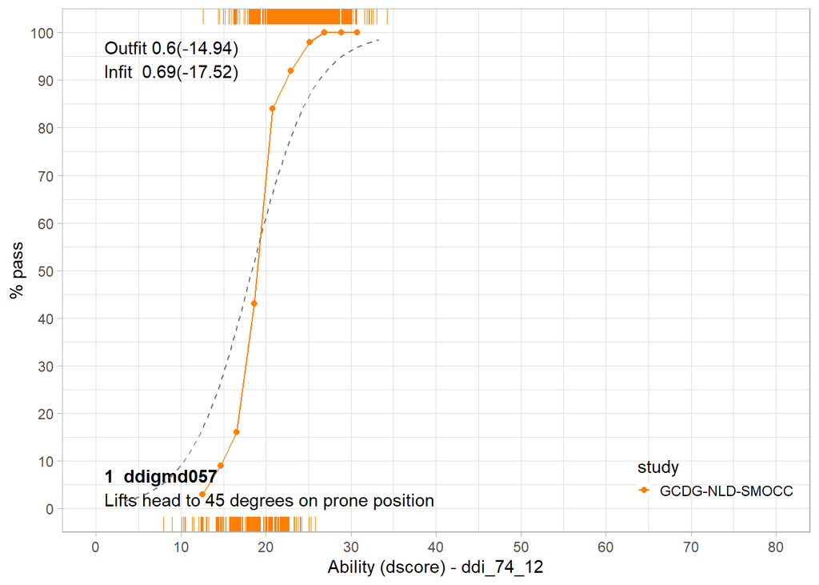

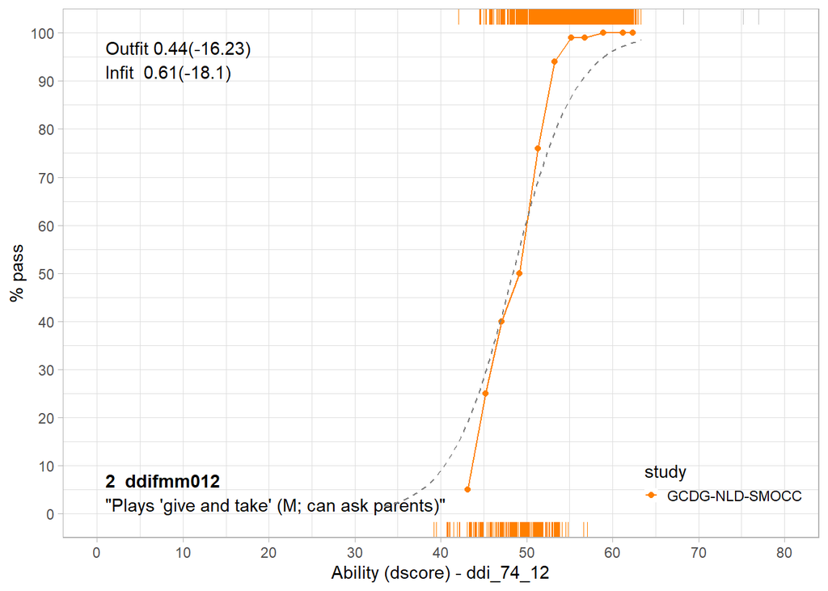

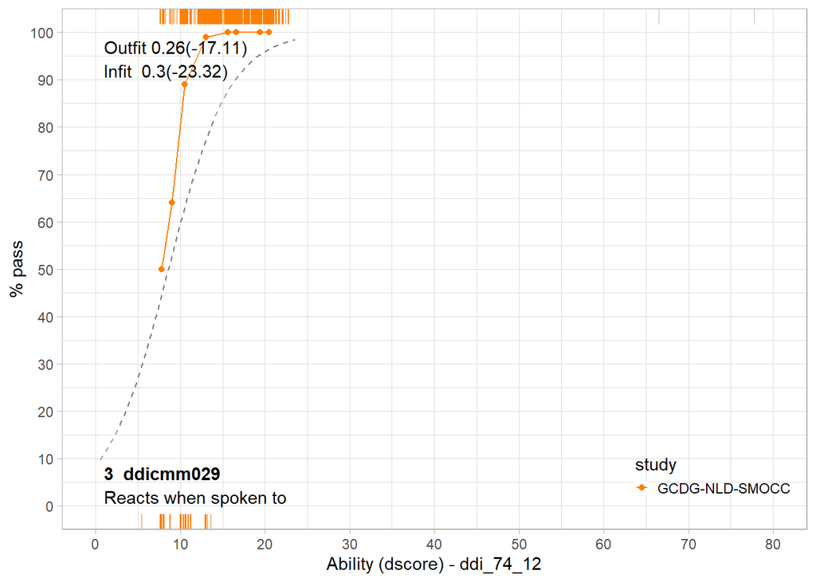

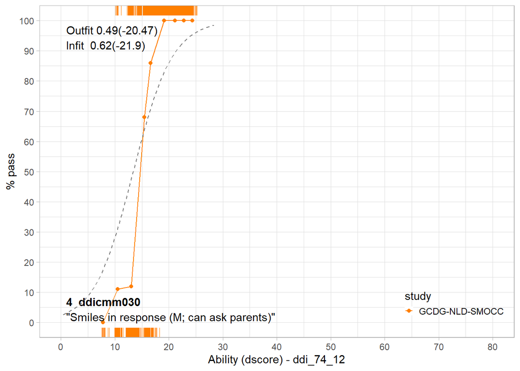

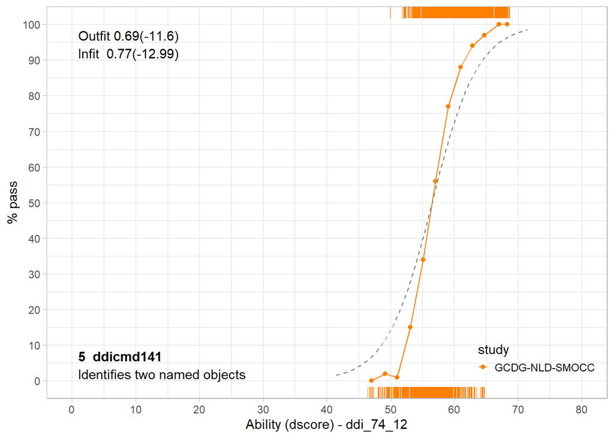

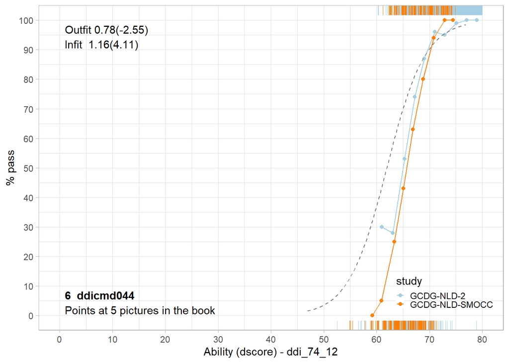

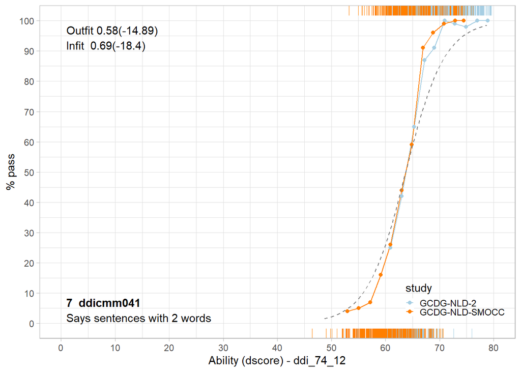

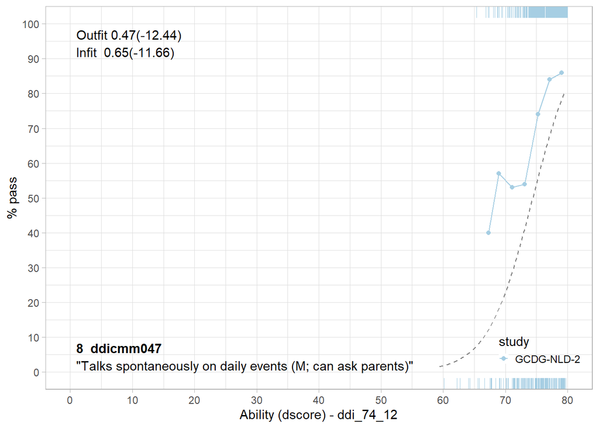

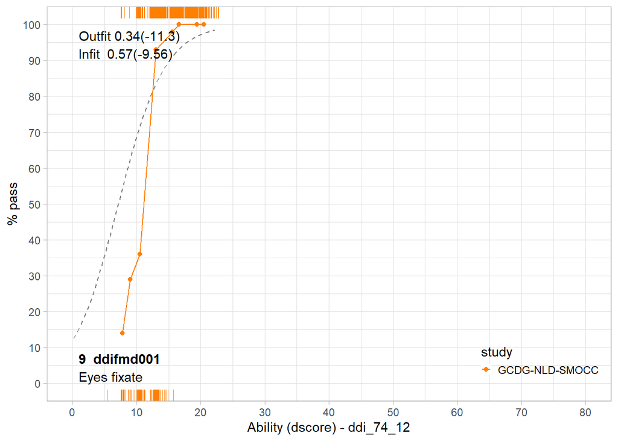

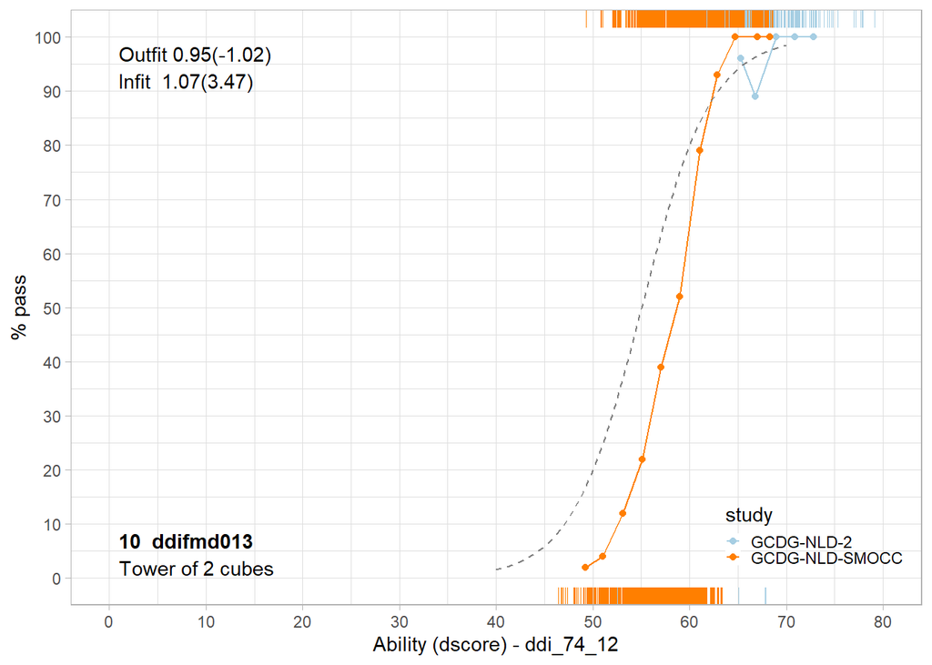

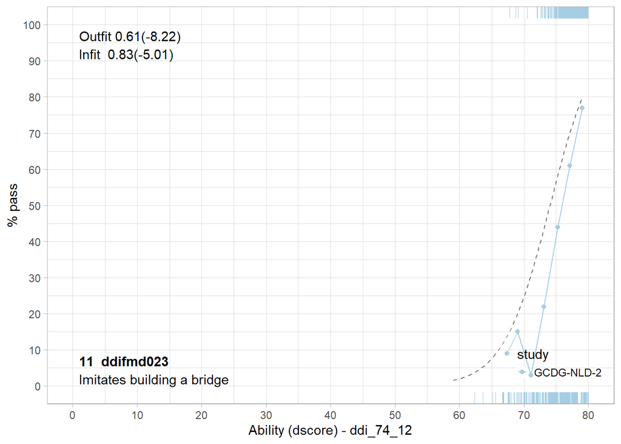

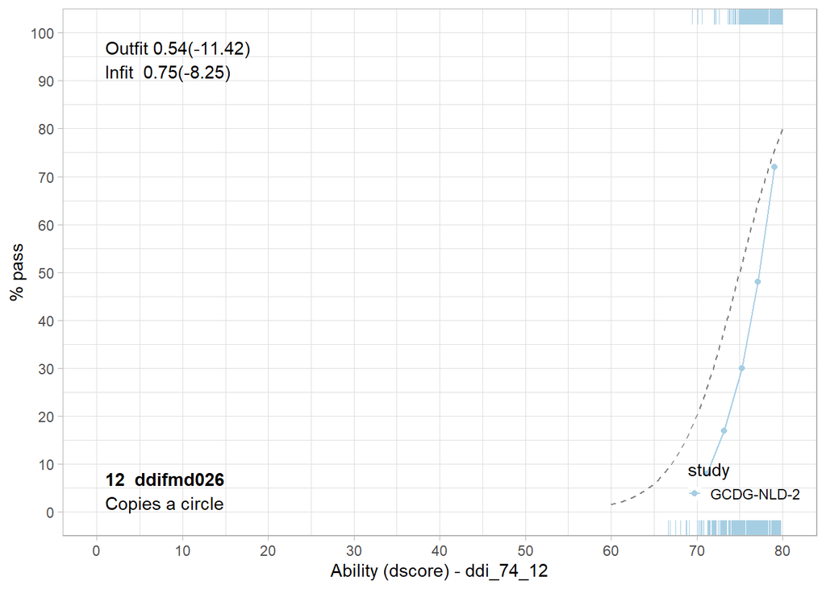

```r
icc
```

We zien voor enkele items verschillen: `ddicmm047`, `ddifmd013`, `ddicmd044`.

- De parameter voor `ddicmm047` lijkt iets te hoog tov de geobserveerde data. In de `ddi` wijkt het label (kenmerk) iets af van de `gsed`, `ddi: Talk spontaneously on daily events (M; can ask parents)` vs `gsed: Talks easily about daily events`. Daarom maken we dit item ook los.
- Voor item `ddifmd013` lijkt de parameter schatting iets lager dan de geobserveerde data, terwijl er veel data beschikbaar is; de afstand is bijna 4 D-score punten. Deze koppelen we ook los.
- Voor item `ddicmd044` lijkt de parameter schatting ook een stuk lager dan de geobserveerde data, dit zien we uit de geobserveerde dat van zowel de SMOCC als de MOM studie (2 data-bronnen). Deze koppelen we ook los.

**Toon/verberg R-code**

```r
model$item_fit |>
  dplyr::filter(item %in% c("ddifmd013", "ddicmm047", "ddicmd044"))
```

```
# A tibble: 3 × 8
  item          n outfit     qo outfit_z infit     qi infit_z
  <chr>     <int>  <dbl>  <dbl>    <dbl> <dbl>  <dbl>   <dbl>
1 ddicmd044  3226  0.781 0.0919    -2.55 1.16  0.0375    4.11
2 ddicmm047  2232  0.474 0.0530   -12.4  0.648 0.0346  -11.7
3 ddifmd013  2949  0.952 0.0468    -1.02 1.07  0.0210    3.47
```

**Toon/verberg R-code**

```r
ddi_fixed <- ddi_fixed[setdiff(names(ddi_fixed),c("ddifmd013", "ddicmm047", "ddicmd044"))]
```

# Modelschatting (4)

Het DDI-uitbreidingsmodel wordt gefit met `dmetric::fit_dmodel()`.

**Toon/verberg R-code**

```r
i <- length(varlist$items)
f <- length(ddi_fixed)
model_name <- paste("ddi", i, f, sep = "_")
model_name
```

```
[1] "ddi_74_9"
```

**Toon/verberg R-code**

```r
model <- dmetric::fit_dmodel(
  data = data,
  varlist = varlist,
  name = model_name,
  b_fixed = ddi_fixed,
  data_package = "",
  transform = modelgsed2510$transform
)
```

We checken de ICC en de itemfit van alle losgekoppelde items:

**Toon/verberg R-code**

```r
model$data_package <- "gseddata" #hack needed to get colors of plots
icc <- dmetric::plot_p_d_item(data = data, model = model, items = c("ddigmd061", "ddifmd010", "ddifmd013", "ddicmm047", "ddicmd044"))
```

```
Item:  1 ddigmd061
Item:  2 ddifmd010
Item:  3 ddifmd013
Item:  4 ddicmm047
Item:  5 ddicmd044
```

**Toon/verberg R-code**

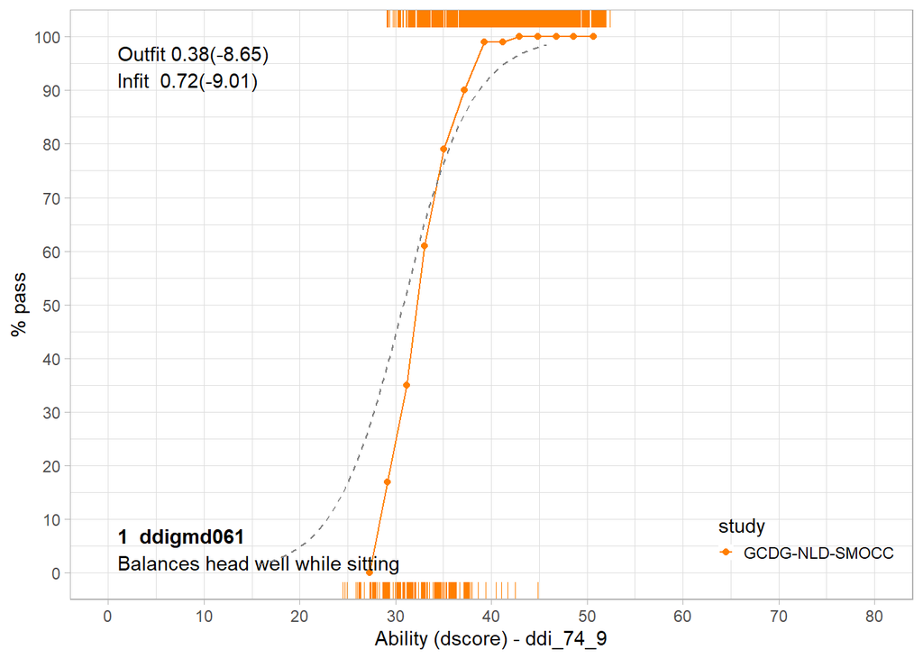

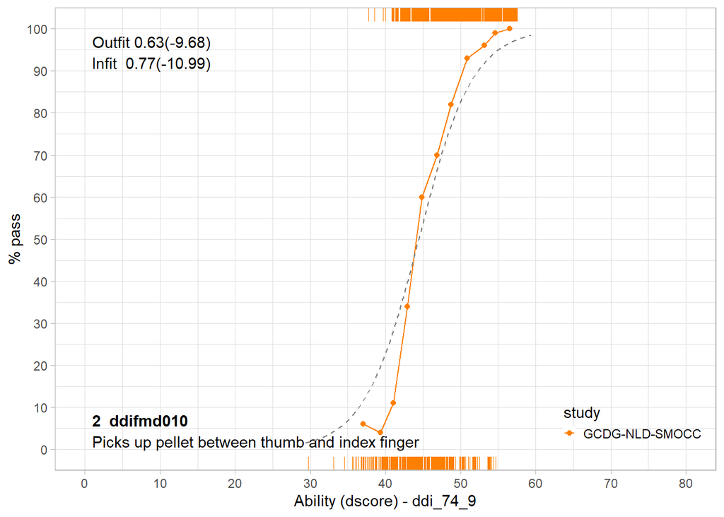

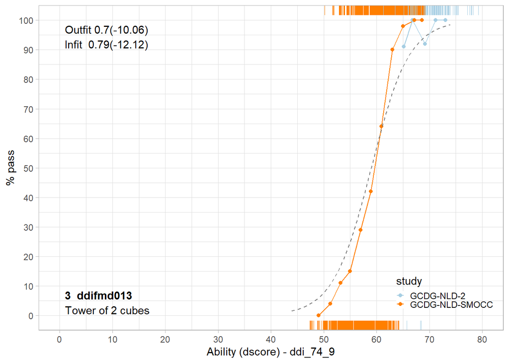

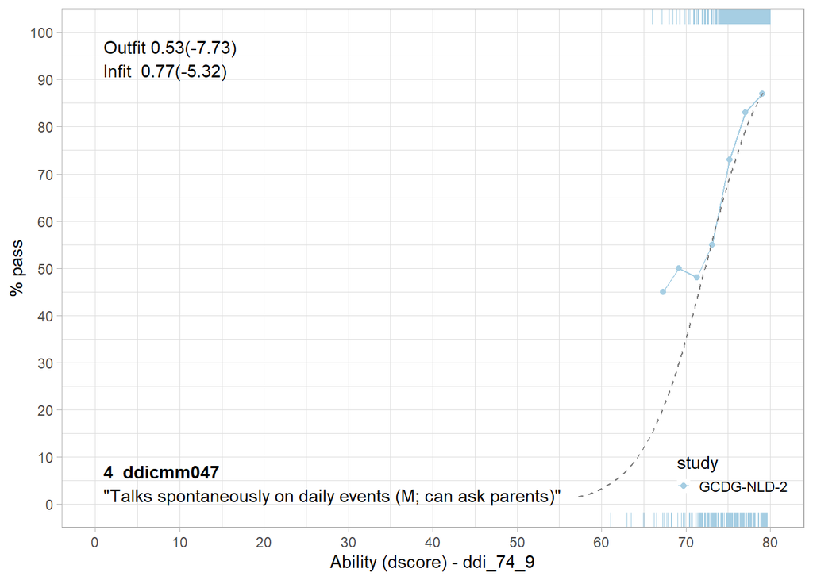

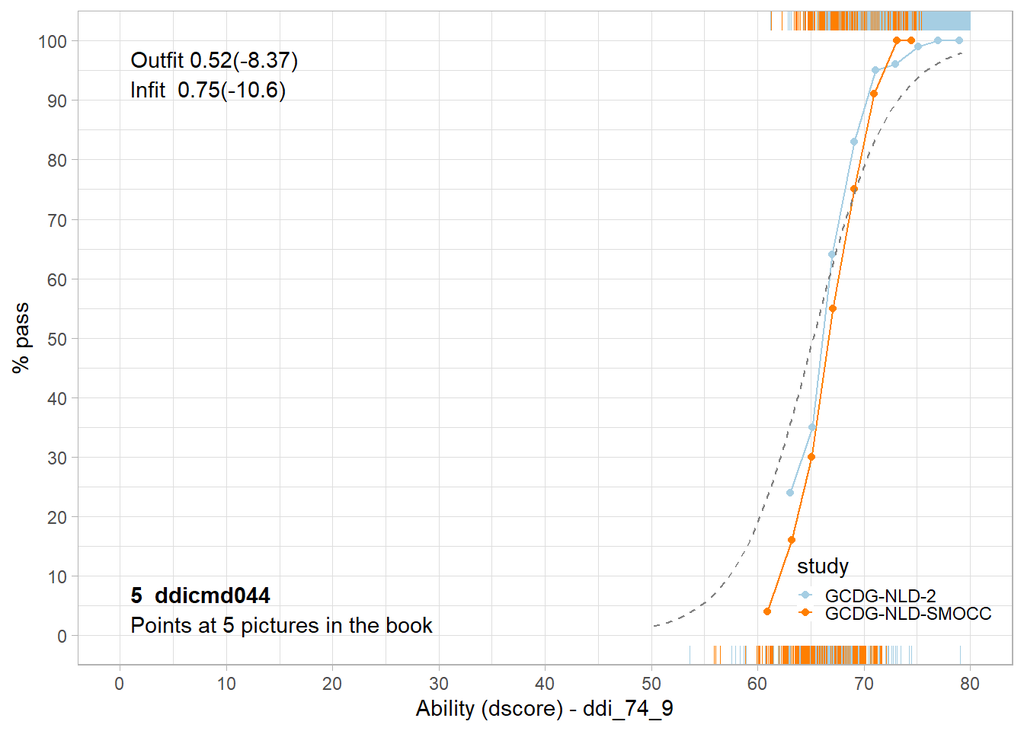

```r
icc
```

Na modelschatting is de itemfit geëvalueerd van alle items in de `ddi` met behulp van infit- en outfitstatistieken.

**Toon/verberg R-code**

```r
model$item_fit |>
  dplyr::filter(outfit > 1.1 | infit > 1.1)
```

```
# A tibble: 0 × 8
# ℹ 8 variables: item <chr>, n <int>, outfit <dbl>, qo <dbl>, outfit_z <dbl>,
#   infit <dbl>, qi <dbl>, infit_z <dbl>
```

> Alles is binnen de marges van 1.4 (threshold Bayleys)

We bekijken ook nog de ICC’s van alle items in het eindmodel.

**Toon/verberg R-code**

```r
model$data_package <- "gseddata" #hack needed to get colors of plots
icc <- dmetric::plot_p_d_item(data = data, model = model, items = varlist$items)
```

```
Item:  1 ddicmm029
Item:  2 ddicmm030
Item:  3 ddicmm031
Item:  4 ddicmm033
Item:  5 ddicmm034
Item:  6 ddicmm036
Item:  7 ddicmm037
Item:  8 ddicmm039
Item:  9 ddicmm041
Item:  10 ddicmm042
Item:  11 ddicmm043
Item:  12 ddicmd044
Item:  13 ddicmm045
Item:  14 ddicmm046
Item:  15 ddicmm047
Item:  16 ddicmm048
Item:  17 ddicmd049
Item:  18 ddicmm050
Item:  19 ddicmd116
Item:  20 ddicmd136
Item:  21 ddicmd141
Item:  22 ddicmd148
Item:  23 ddifmd001
Item:  24 ddifmd002
Item:  25 ddifmd003
Item:  26 ddifmm004
Item:  27 ddifmd005
Item:  28 ddifmd007
Item:  29 ddifmd008
Item:  30 ddifmm009
Item:  31 ddifmd010
Item:  32 ddifmd011
Item:  33 ddifmm012
Item:  34 ddifmd013
Item:  35 ddifmm014
Item:  36 ddifmd015
Item:  37 ddifmm016
Item:  38 ddifmd017
Item:  39 ddifmd018
Item:  40 ddifmm019
```

[output cut: 19 more lines]

```
Item:  60 ddigmd063
Item:  61 ddigmm064
Item:  62 ddigmm065
Item:  63 ddigmm066
Item:  64 ddigmm067
Item:  65 ddigmd068
Item:  66 ddigmd069
Item:  67 ddigmd070
Item:  68 ddigmd071
Item:  69 ddigmd072
Item:  70 ddigmm073
Item:  71 ddigmd074
Item:  72 ddigmd146
Item:  73 ddigmd168
Item:  74 ddigmd268
```

**Toon/verberg R-code**

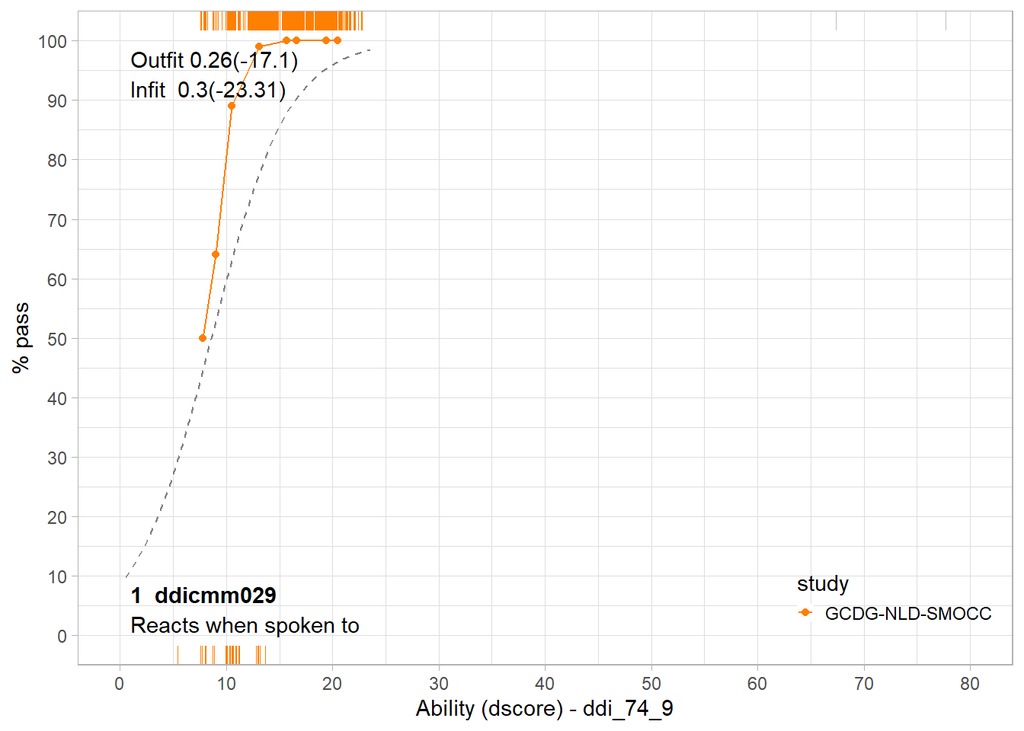

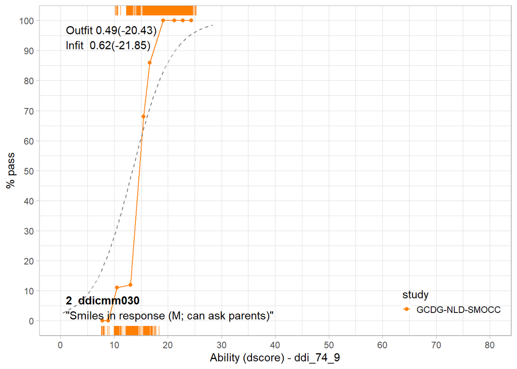

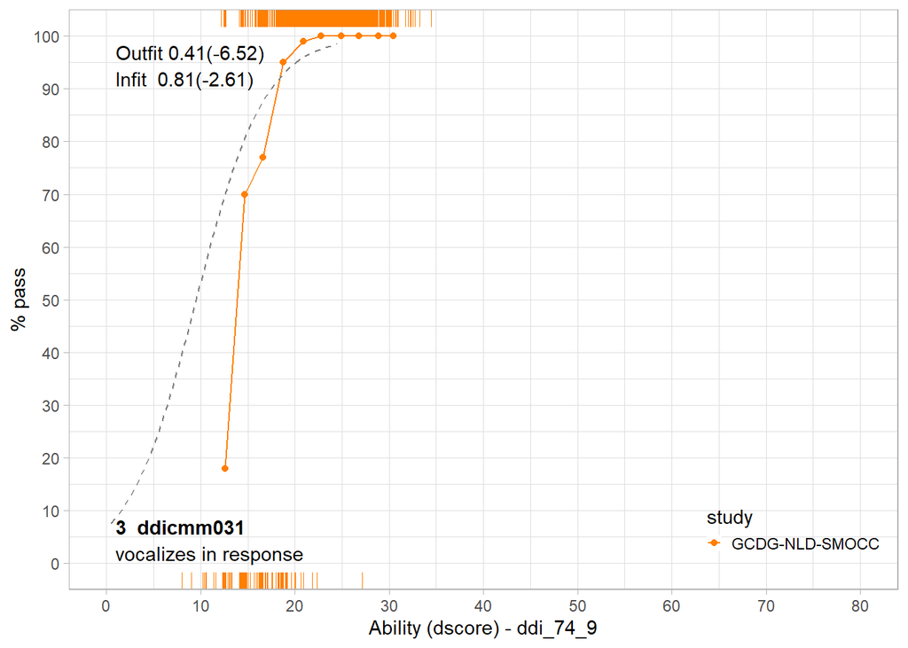

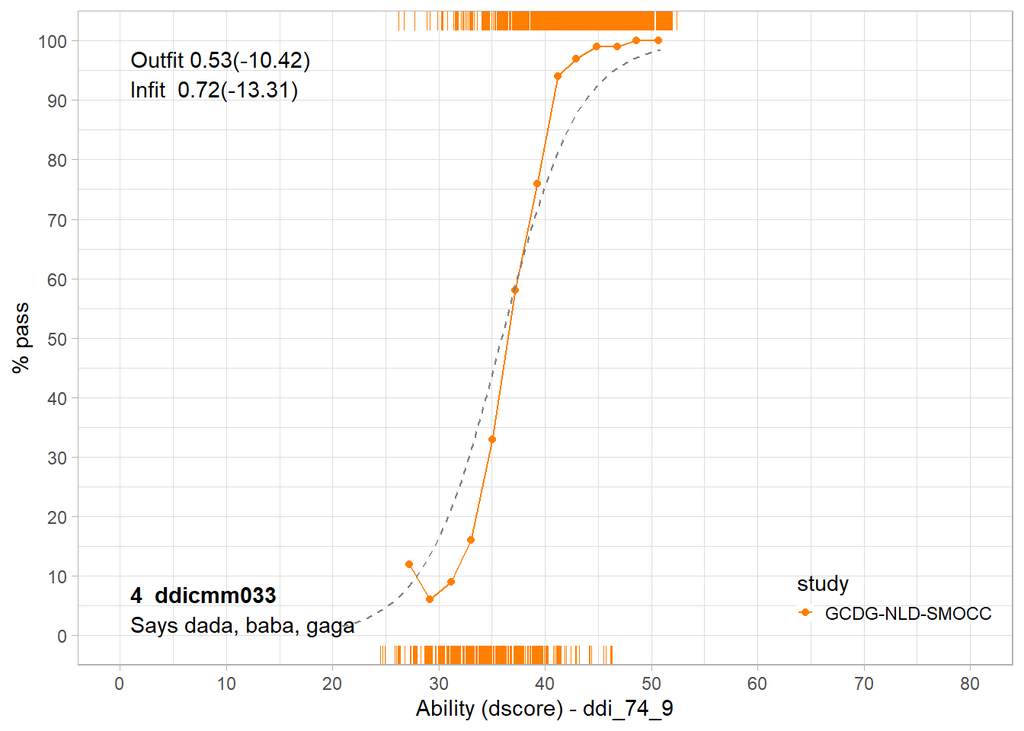

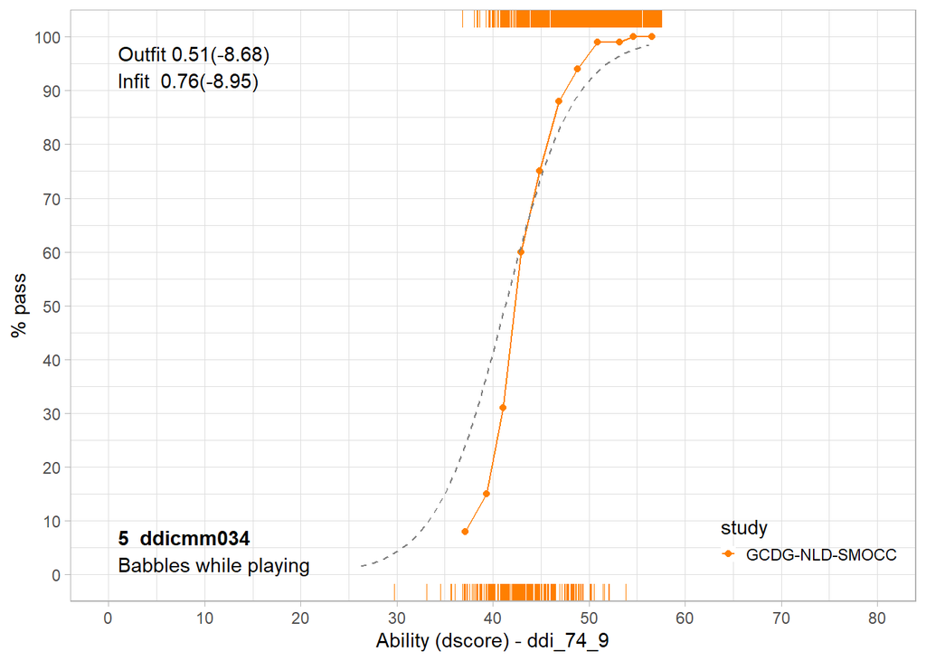

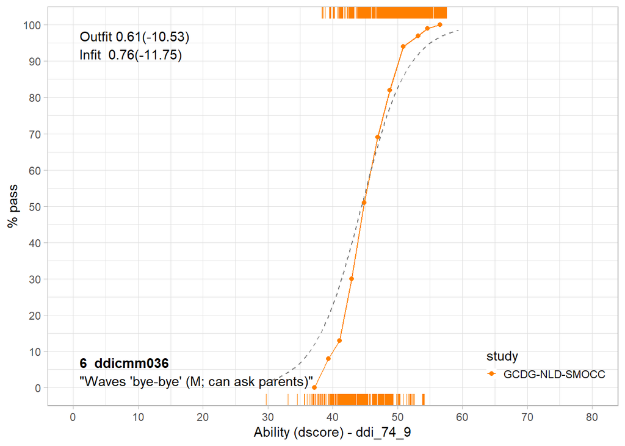

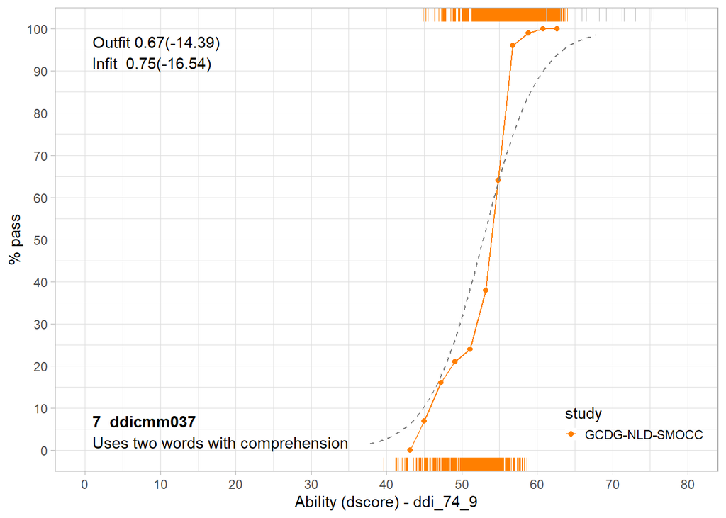

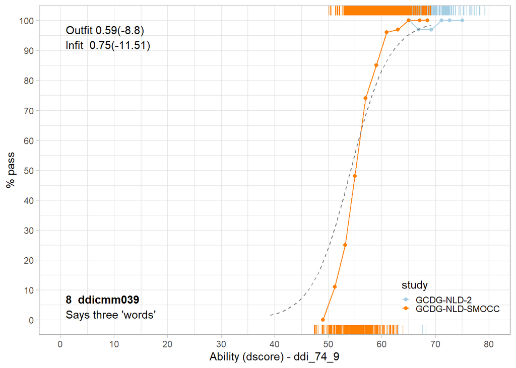

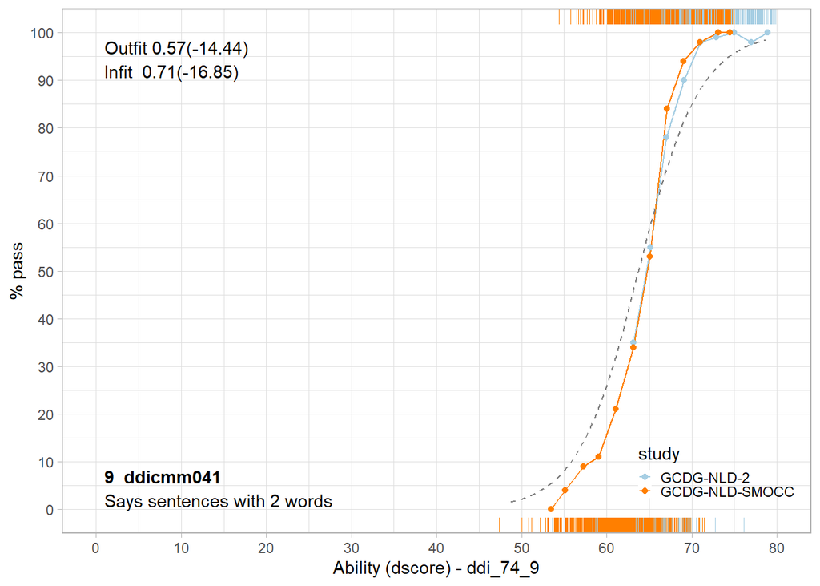

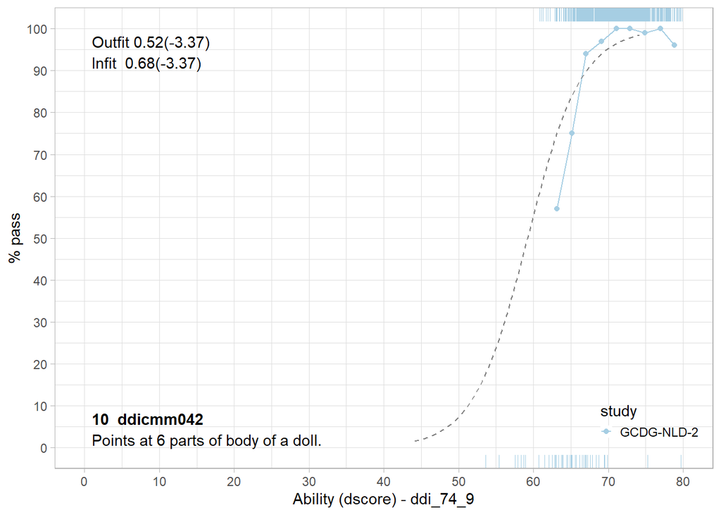

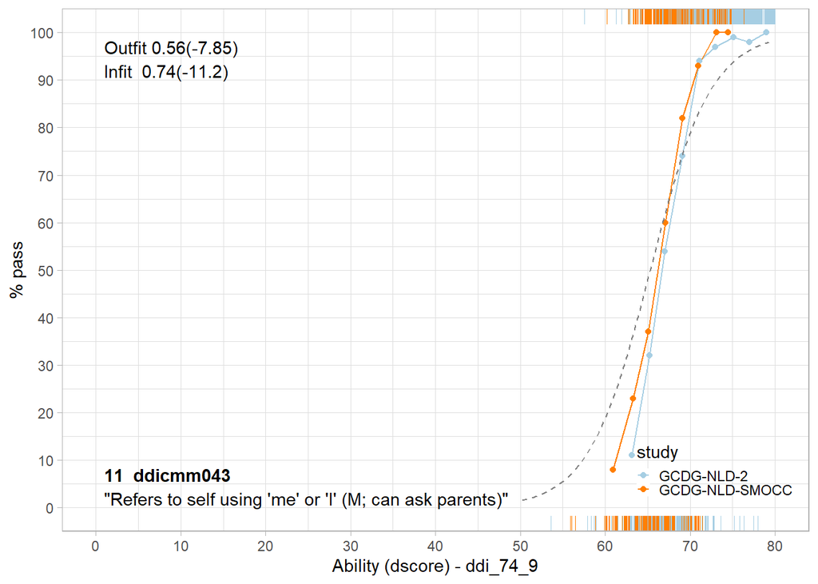

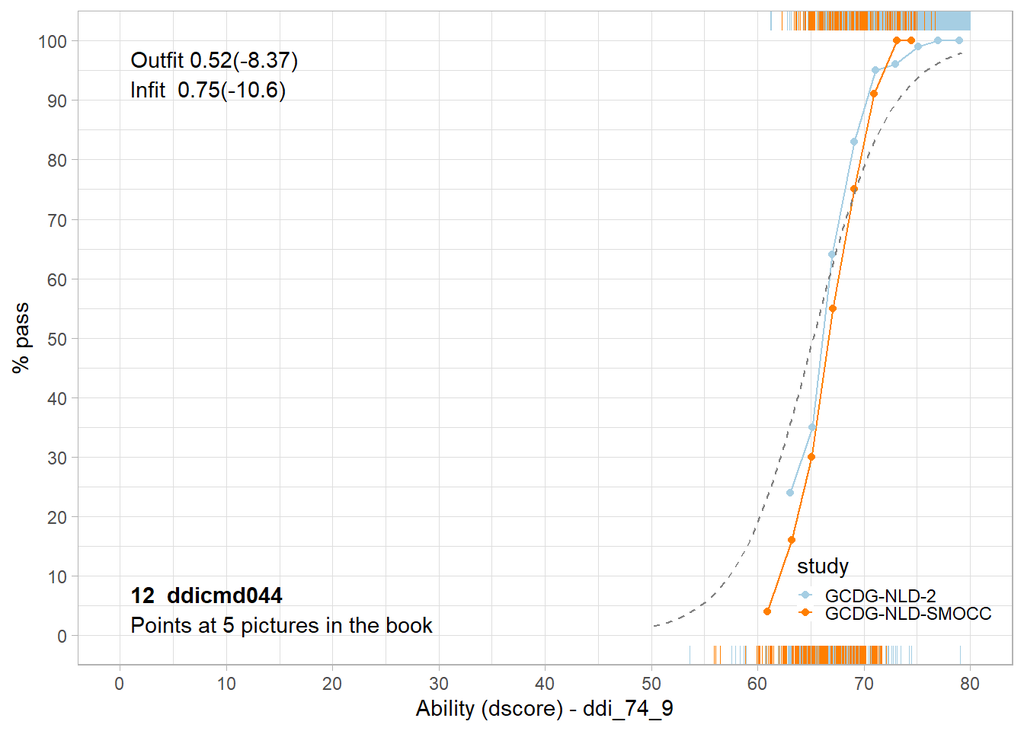

[62 more figures not shown]

```r
icc
```

## Grafische modeldiagnostiek

Het eindmodel wordt opgeslagen samen met de ICC plots en D-score plots via `dmetric::plot_dmodel()`.

**Toon/verberg R-code**

```r
path <- file.path("pad", "naar", model_name)
dir.create(path, showWarnings = FALSE, recursive = TRUE)

saveRDS(model, file = file.path(path, "model.Rds"), compress = "xz")

r <- dmetric::plot_dmodel(
  data = data,
  model = model,
  path = path,
  ref_name = "preliminary_standards",
  maxy = 85,
  xbreaks = seq(0, 80, 10)
)
```

# Opslaan nieuwe calibratie

De item parameters zijn opgeslagen in `data/itembank_vwc` en dus onderdeel van `dscoreddi::itembank_vwc`.

# Vergelijking met eerdere D-score calibratie

Om de impact van de update te beoordelen, zijn DDI/Van Wiechen-itemparameters op basis van de eerdere GSED2406-calibratie vergeleken met de nieuwe GSED2510-calibratie.

**Toon/verberg R-code**

```r
library(dscoreddi)
itembank_gsed2510 <- model$itembank |>
  select(item, tau, label) |>
  mutate(decompose_itemnames(item),
         key = "gsed2510") |>
  select(key, everything())

ibcomp <- itembank_vwc |> filter(key == "gsed2406") |>
  bind_rows(itembank_gsed2510) |> pivot_wider(names_from = "key", values_from = "tau")


cor(ibcomp$gsed2406, ibcomp$gsed2510, use = "pairwise.complete.obs")
```

```
[1] 0.9901975
```

Een scatterplot kan worden gebruikt om systematische verschuivingen, afwijkende items of niet-lineaire verschillen tussen calibraties zichtbaar te maken. We verwachten hier wel enkele verschillen tussen de twee modellen, met name voor de lagere D-scores.

**Toon/verberg R-code**

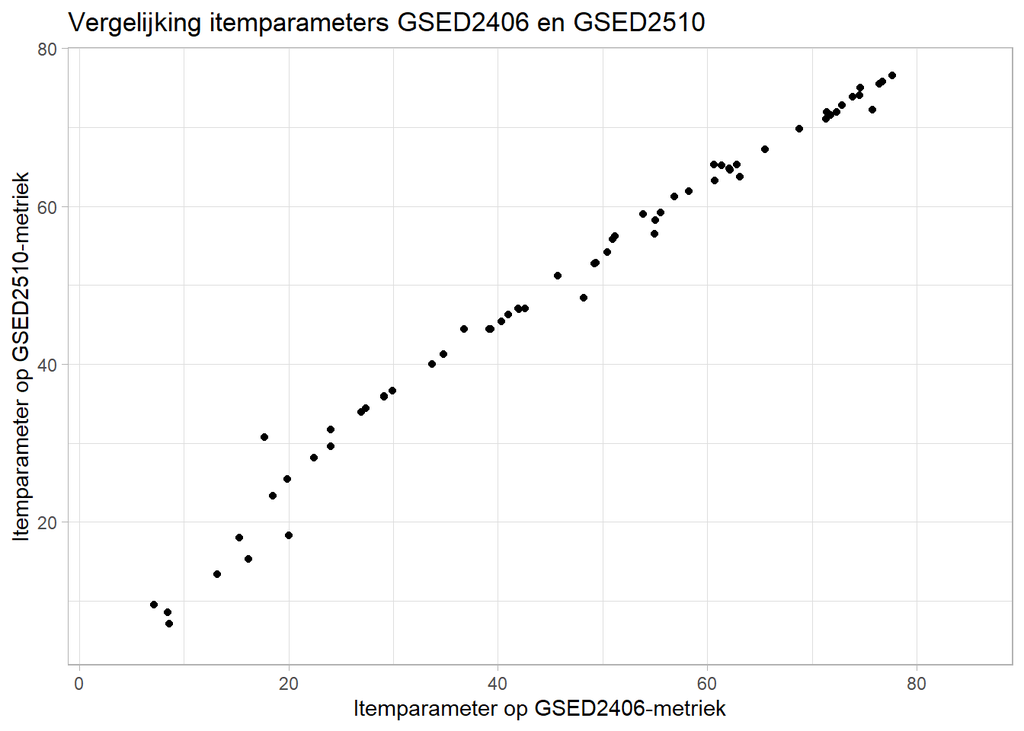

```r
ggplot(ibcomp, aes(gsed2406, gsed2510)) +
  geom_point() +
  labs(
    x = "Itemparameter op GSED2406-metriek",
    y = "Itemparameter op GSED2510-metriek",
    title = "Vergelijking itemparameters GSED2406 en GSED2510"
  )
```

De D-score op basis van het voorgaande model kan vergeleken worden met de D-score op basis van het huidige model. De correlatie tussen de D-score en ook de DAZ is hoog. Als we de absolute D-scores vergelijken in een plot zien we dat het nieuwe model de D-scores hoger inschat.

**Toon/verberg R-code**

```r
dsc_2406 <- dscore(data = data, key = "gsed2406", population = "dutch", xname = "agedays", xunit = "days", itembank = dscoreddi::itembank_vwc)
dsc_2510 <- dscore(data = data, key = "gsed2510", population = "GSED-NLD", xname = "agedays", xunit = "days", itembank = itembank_gsed2510)

cor(dsc_2406$daz, dsc_2510$daz, use = "pairwise.complete.obs")
```

```
[1] 0.9600149
```

**Toon/verberg R-code**

```r
cor(dsc_2406$d, dsc_2510$d, use = "pairwise.complete.obs")
```

```
[1] 0.9969097
```

**Toon/verberg R-code**

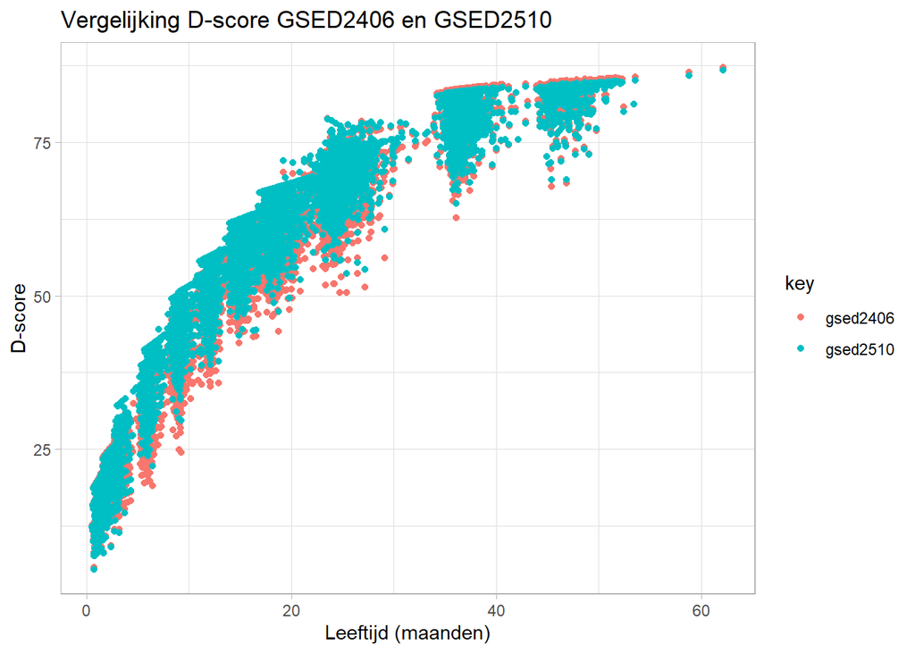

```r
dsc_df <- bind_rows(
  {dsc_2406 |> mutate(key = "gsed2406")},
  {dsc_2510 |> mutate(key = "gsed2510")}
)

ggplot(dsc_df, aes(a*12, d, group = key, color = key)) +
  geom_point() +
  labs(
    x = "Leeftijd (maanden)",
    y = "D-score",
    title = "Vergelijking D-score GSED2406 en GSED2510"
  )
```

De standardisatie voor leeftijd (DAZ) is in beide modellen nu op een andere populatie gebasseerd. Voor het GSED2406 model is dit gebaseerd op dezelfde data die hier is gebruik voor deze kalibratie. Voor het GSED2510 model hebben we gebruik gemaakt van de Nederlandse kinderen dat de GSED heeft ingevuld. De vergelijking kan dus niet volledig 1-op-1 gemaakt worden.

Voor de toekomst zouden we de referentie voor GSED2510 willen maken op basis van alle Nederlandse data die we beschikbaar hebben.

**Toon/verberg R-code**

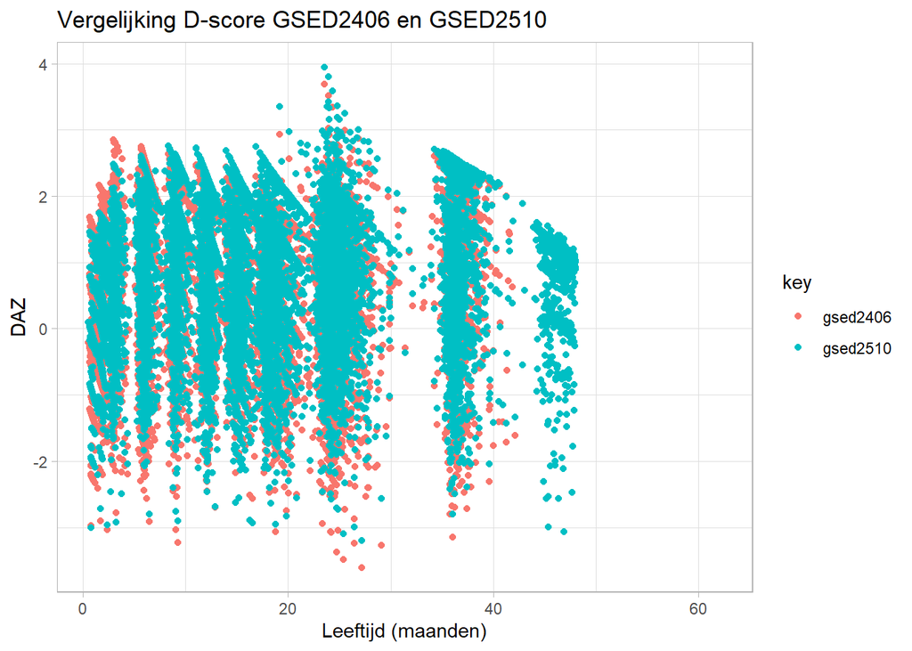

```r
ggplot(dsc_df, aes(a*12, daz, group = key, color = key)) +
  geom_point() +
  labs(
    x = "Leeftijd (maanden)",
    y = "DAZ",
    title = "Vergelijking D-score GSED2406 en GSED2510"
  )
```

# Voorlopige interpretatie

Op basis van de huidige pipeline is het technisch mogelijk om het GSED2510-model uit te breiden met DDI/Van Wiechen-items. Door gebruik te maken van DDI-items die direct gekoppeld zijn aan bestaande GSED-items, kunnen nieuwe itemparameters op de GSED2510-metriek worden geplaatst. De resulterende itemparameters vormen de basis voor het berekenen van D-scores in Nederlandse JGZ-data.

# Reproduceerbaarheid

**Toon/verberg R-code**